# From Messy Data to Research Insights

Data Analytics for Finance

Caspar David Peter

peter@rsm.nl

Rotterdam School of Management, Accounting Department

# Introduction

## Introduction

### Who am I?

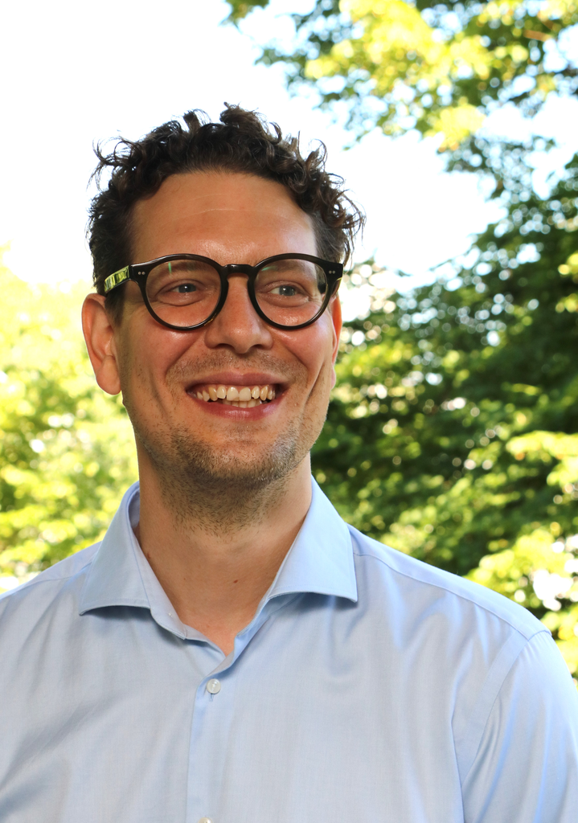

**Caspar David Peter**

- 🏢 Rotterdam School of Management
- 👷 Associate Professor
- 🏫 Doctorate (WHU)
- 🏫 Dipl.-Ök. (RUB)
- 👶 Bochum, Germany
- 🏠 Rotterdam, Netherlands
- 🍞🧈 Economic consequences of transparency

# Setting the Stage

## Setting the Stage

### Why are we here?

#### The struggle is real

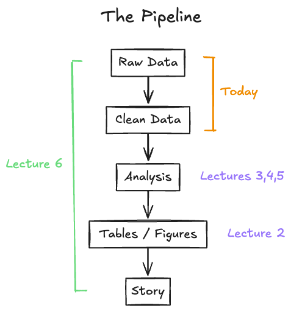

#### What we gonna do about it?

- L1-2: Data wrangling & visualization (the foundation)
- L3-4: Regression & panel methods (the workhorse)
- L5: Event studies & Fama-MacBeth (specialized tools)
- L6: Replication workshop (putting it together)

## Setting the Stage

### Logistics

#### Lectures

- **Dates & Times & Rooms**: [Timetable](https://timetables.eur.nl/schedule)
- **Fomat**: 6 × ~ 3-hour sessions
- **No mandatory attendance**, but highly recommended!

#### Resources

- Course Canvas page
- [Course website](https://caspardp.github.io/rsm-data-analytics-for-finance-public/)
- Textbooks: Huntington-Klein (2022) and Verbeek (2021)
- Required readings (see lecture slides)

## Setting the Stage

### Logistics

#### Assignments

- 6 assignments (weekly, after each lecture)
- Assignment 6 is a “replication” project
- Access via browser (JupyterHub)
- No local installation needed!
- Deadlines/Details in assignment documents
- We do a walkthrough later today

#### How to succeed

- Complete assignments **on time**
- Grading
  - All assignments must be completed
  - Assignmnets are equally weighted
  - Fail if overall assignmnet score < 5.5

## Setting the Stage

### Philosophy of the course

> This is NOT a coding course!

#### What this course is NOT

- A Stata coding tutorial
- A software certification
- About memorizing syntax

#### What this course IS

- A course about research *design* and empirical *methods*
- Learning how to think about data and causality EVERYWHERE
- Understanding what steps you need to take and why
- A fallback when you get stuck in your thesis work

## Setting the Stage

### Elephant in the room: Stata

#### The role of coding

- Implementation is how we deepen understanding
- Hands-on practice makes abstract concepts concrete
- But if you understand the concepts, you can implement in any language (Python, R, Stata, Julia…)

#### Why Stata?

- Research lingua franca in finance/accounting—most papers use it
- Your thesis supervisor likely uses it
- Replication packages are overwhelmingly in Stata

## Setting the Stage

### Takeaway

> If you understand what you’re trying to do and why, the coding is the easy part. If you don’t understand the research design, no amount of syntax knowledge will save you.

#### On (NOT) using LLMs

- The course manual is clear on this topic
- *“…if you don’t understand what you’re asking for, you won’t know if the answer is right.”*
- Can I check if you used LLMs? No.
- But latest during your thesis writing and defense, it will show if you don’t understand what you did.

## Setting the Stage

### Core Skills 2025 - World Economic Forum

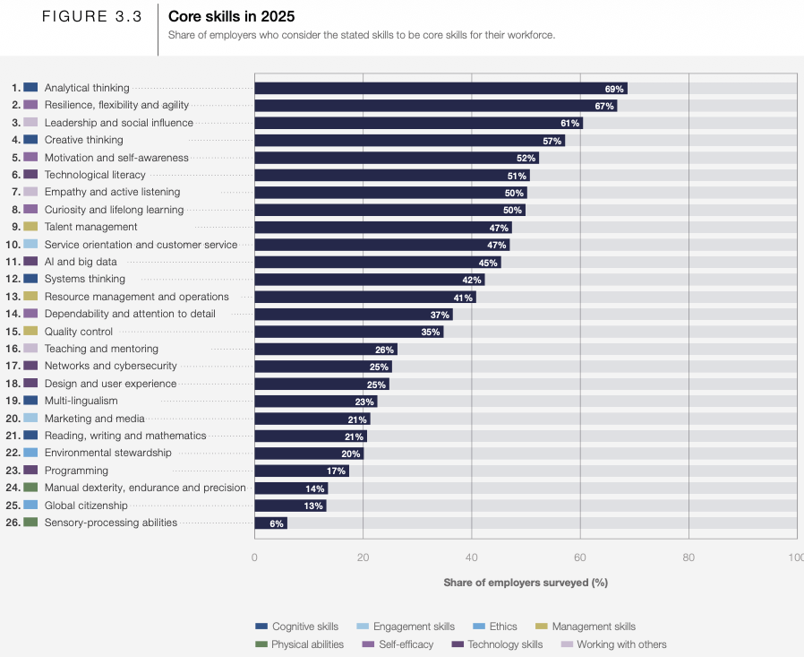

[Future of Jobs Report2025](https://reports.weforum.org/docs/WEF_Future_of_Jobs_Report_2025.pdf)

# Organizing Research

# Organizing Research

Your future self will thank you!

## Organizing Research

### Your future self will thank you!

#### Project structure

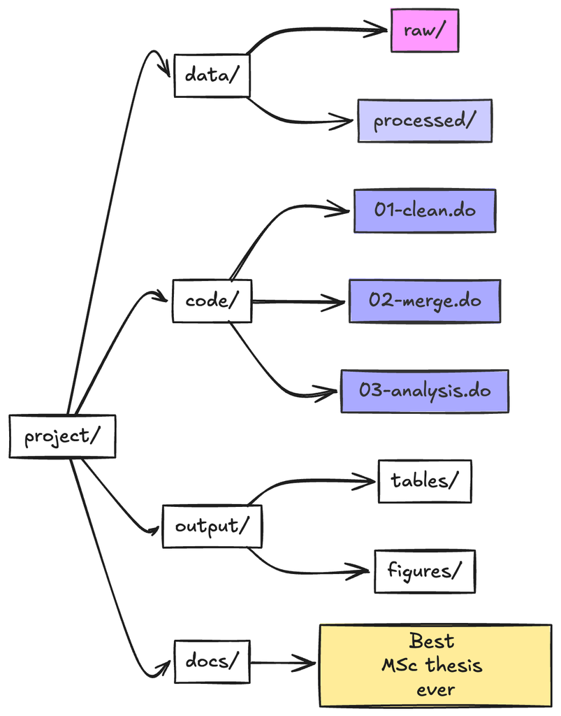

#### Key principles (adjust to your needs)

- Raw data is sacred—never modify it directly
- Running order, e.g. number your scripts in execution order
- One script = one purpose
- Document every decision that involves judgment in the code with comments

## Organizing Research

### Reproducibility & Quarto

#### Thesis requirements

- Goal: Replicability of the scientific results
- All steps from raw data to final results must be documented
- MSc thesis ideally one source file (e.g., “.qmd” file)
  - Includes code, output, and narrative (references, etc.)
- More details in the thesis manual!

#### Assignments

- Assignments are on JupyterHub
  - “.ipynb” files (Jupyter Notebooks)
  - Run code cells interactively in the browser
- Follow same principles as for thesis work
  - They combine code, output, and narrative
  - Run from top to bottom to reproduce results
- Assignments mimick thesis workflow as closely as possible

## Organizing Research

### Stata, Python, and Quarto

[figure not shown]

# Data Structure & Tidy Data

## Data Structure & Tidy Data

### What is tidy data?

**Definition**

- Each variable is a column
- Each observation is a row
- Each type of observational unit is a table

#### Why is tidy data important?

- Almost **every statistical command** expects tidy data
- (Data) Cleaning means getting from raw to tidy data
- Easier to understand, document, and share

## Data Structure & Tidy Data

### Tidy versus “messy” data

#### “Messy” data (*wide format*)

| Student ID | Score_22 | Score_23 | Score_2024 |
| --- | --- | --- | --- |
| S001abc | 85 | 90.0 | 92.0 |
| S002_ | 78.0 | 81 | 85 |
| S 003 | 92 | 95 | 98.0 |

#### Tidy data (*long format*)

| Student ID | Year | Score |
| --- | --- | --- |
| S001 | 2022 | 85 |
| S001 | 2023 | 90 |
| S001 | 2024 | 92 |
| S002 | 2022 | 78 |
| S002 | 2023 | 81 |
| S002 | 2024 | 85 |
| S003 | 2022 | 92 |
| S003 | 2023 | 95 |
| S003 | 2024 | 98 |

## Data Structure & Tidy Data

### (Typical) Finance data structures

- Cross-sectional: One observation per firm (snapshot)
- Time series: Multiple observations over time for one firm
- Panel data: Multiple firms × multiple time periods → firm-year observations

> Most of your thesis work will use panel data. We’ll return to this in *Lecture 4*

## Data Structure & Tidy Data

### What else is there?

#### Other data structures

- Hierarchical / nested data
  - XBRL data
  - JSON data
  - Lists in R/Python
  - Dictionaries in Python
- Spatial data
  - Shapefiles, GeoJSON
  - GIS software (ArcGIS, QGIS)

#### Database types

- Relational databases
  - SQL databases, e.g. PostgreSQL (WRDS), MySQL (backend of many web apps)
  - NoSQL databases, e.g. MongoDB (document storage)
- Time-series databases
  - InfluxDB, TimescaleDB

> These are beyond the scope of this course!

## Data Structure & Tidy Data

### Each one teach one: Where to get finance data?

#### Key data sources

##### WRDS (Wharton Research Data Services)

- Prices: CRSP (US), Compustat Global, and Datastream/LSEG (global)
- Intraday prices: TAQ
- Listed firms’ fundamentals: CRSP, Compustat, Bureau van Dijk
- Private firms: Bureau van Dijk (Orbis, Amadeus)
- Institutional ownership: Thomson Reuters Institutional (13F) Holdings
- Board and Executives: BoardEx, ExecuComp, Incentive Lab
- Analyst forecasts: I/B/E/S
- Auditor data: Audit Analytics
- 10-K/SEC filings: EDGAR
- ESG data: MSCI ESG, Sustainalytics

##### Library & other sources

- Mutual funds, ETFs, etc.: Morningstar Direct: Mutual funds, ETFs, etc.
- Mergers & Acquisitions: SDC Platinum
- Text data:
  - REddit (via API)
  - SEC filings (via EDGAR or WRDS)
  - News data (via Bloomberg, Refinitiv, or other providers)
- Macroeconomic data: FRED, World Bank, IMF, OECD

## Data Structure & Tidy Data

### Each on teach one: How to access Data?

#### Access via Library

- On-campus access: Direct access via IP recognition
- Off-campus access: **Remote desktop** via RSM VPN
- See [Erasmus Data Service Centre (EDSC)](https://www.eur.nl/en/library/research-support/edsc/databases)

#### Accessing WRDS

##### WRDS via web interface

- Point-and-click data extraction
- Export to CSV, Stata, SAS, R, Python
- Good for one-off downloads

##### WRDS via API

- Programmatic access via Python, R, Stata (and SAS)
- Good for reproducible research workflows
- See [WRDS documentation](https://wrds-www.wharton.upenn.edu/pages/support/programming-wrds/) for details

The course assignments will provide data files directly, so you don’t need to set up WRDS access for this course.

# Merging & Identifiers

## Merging & Identifiers

### Why do we care?

- Real-world data is messy and fragmented
- Different databases use different identifiers
- Merging datasets is *essential* for comprehensive analysis
- Understanding identifiers helps avoid merge errors and data inconsistencies

> Most important step to get from raw data to analysis-ready data!

## Merging & Identifiers

### The Identifier Zoo

Common Identifiers Across Major Finance Databases

| Source | CRSP | Compustat | Thomson Refinitiv |
| --- | --- | --- | --- |
| CRSP | Linking within the CRSP Environment | CRSP/Compustat Merged (CCM) | MFLINKs for Mutual Fund Linking; Linking through CUSIP; 13F Linking Program |
| Compustat | CRSP/Compustat Merged (CCM); Using Compustat Historical Identifiers | Linking within the Compustat Environment using GVKEY | Link through CUSIP |
| Capital IQ | CIQ company ID linked to GVKEY and then to CRSP | Linking within Capital IQ | Link through CUSIP, ISIN or Ticker |
| IBES | IBES CRSP Link | Link through CRSP | Link through Security Mapping |
| Audit Analytics | Link through Compustat | Link through CIK Link (primary); Link through Ticker (secondary) | Link these two products using Compustat |
| BoardEx | Link with CRSP and Compustat | Link with CRSP and Compustat | TR Insiders Boardex Link |
| Bond: TRACE / Mergent FISD | Bond CRSP Link | Link through CRSP | Link through CRSP |
| Bureau van Dijk | Link through ISIN (CUSIP) for US Companies | Link through CRSP | Link through ISIN or SEDOL |

Source: [WRDS Linking Matrix](https://wrds-www.wharton.upenn.edu/pages/wrds-research/database-linking-matrix/)

## Merging & Identifiers

### The Identifier Zoo

#### Why so many?

- Different databases, different purposes, historical reasons
- CRSP uses PERMNO, Compustat uses GVKEY, SEC filings use CIK, everyone uses CUSIP (but which version?)

| Identifier | Source<sup>1</sup> | What it identifies | Persistence |
| --- | --- | --- | --- |
| CUSIP | Compustat | Security | Can change! |
| GVKEY | Compustat | Company | Stable |
| PERMNO | CRSP | Security | Stable |
| ISIN | Refinitiv | Security | Can change! |
| TICKER | Refinitiv | Security | Can change! |

[^1]: Identifiers may be available in multiple databases; source indicates common origin.

## Merging & Identifiers

### The Identifier Zoo

#### Why so many?

- Different databases, different purposes, historical reasons
- CRSP uses PERMNO, Compustat uses GVKEY, SEC filings use CIK, everyone uses CUSIP (but which version?)

**Key insights**

- Always check which identifier(s) your datasets use before merging!
- Check WRDS to find linking tables between identifiers (e.g., CRSP-Compustat link)
- Saves a ton of work and headache later!

## Merging & Identifiers

### Merge Types

#### Fundamentals

##### 1:1 Merge (a.k.a. inner-join)

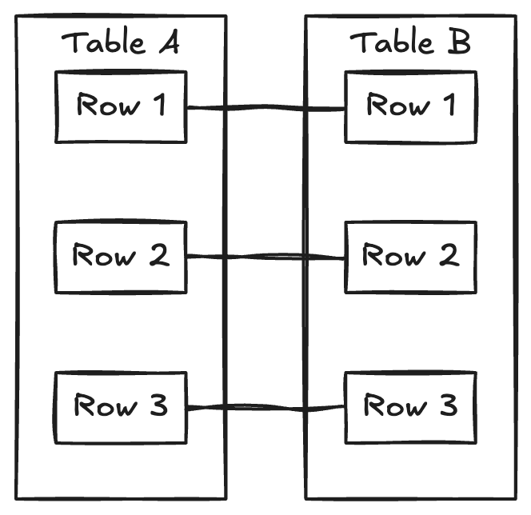

##### What to watch out for?

- Ensure both datasets have unique keys
- Check for unexpected duplicates before merging
- Non-matches: Decide how to handle them (**drop**)

## Merging & Identifiers

### Merge Types

#### Fundamentals

##### 1:m Merge (a.k.a. left-join)

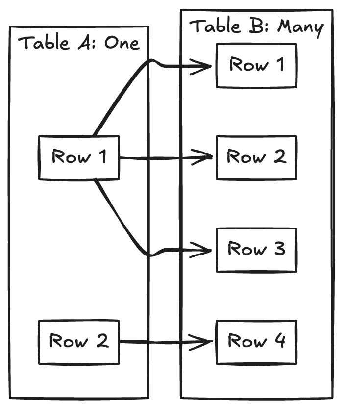

##### m:1 Merge (a.k.a. right-join)

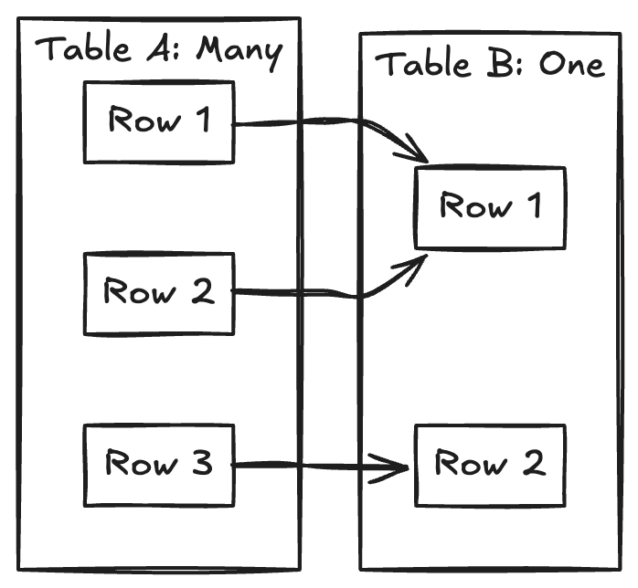

## Merging & Identifiers

### Merge Types

#### What to watch out for?

- Ensure both datasets have unique keys
- Check for unexpected duplicates before merging
- Understand the direction of the merge (which dataset is “master”)
- Decide how to handle non-matches (keep/drop)
  - Keep all from “master” dataset

## Merging & Identifiers

### Merge Types

#### Fundamentals

##### m:m Merge

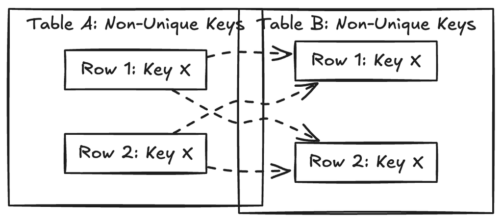

##### What to watch out for?

- **Avoid m:m merges whenever possible!**
- Usually indicates a problem with the data or merge keys
- Can lead to **data explosion** and incorrect results
- If unavoidable, carefully check the results and understand implications

## Merging & Identifiers

### Example

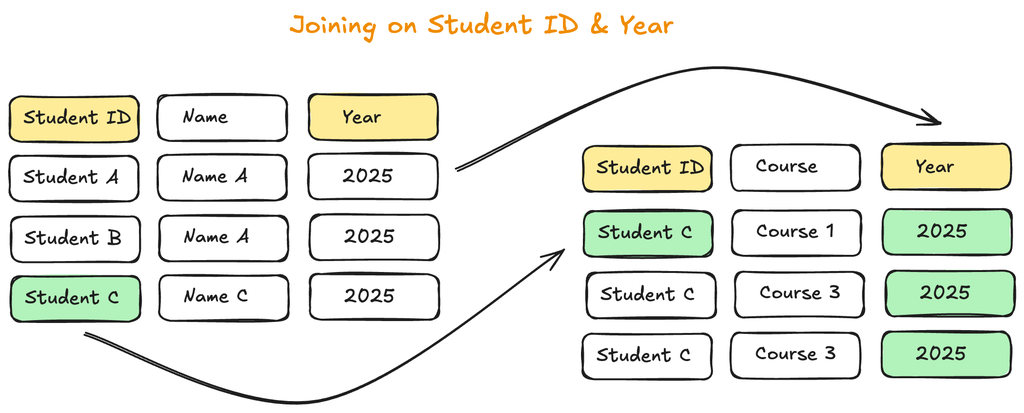

## Merging & Identifiers

### Example

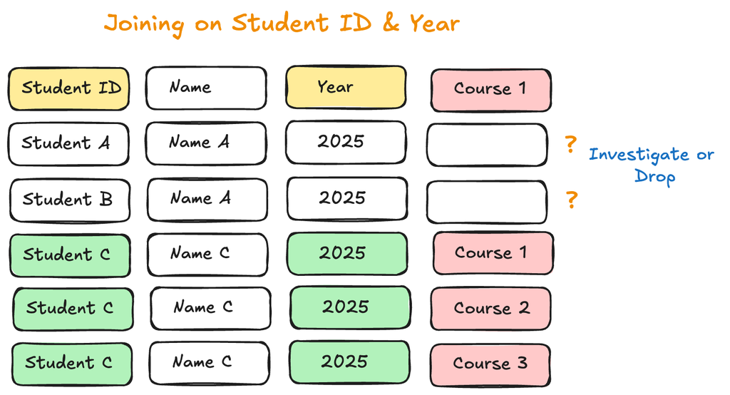

## Merging & Identifiers

### Reality check

#### Best practices for merging data

- Check uniqueness before merging
- Check match rates after merging
- Investigate unmatched observations—are they expected?

#### Examples

- Merging firm fundamentals (Compustat) with stock prices (CRSP)
  - Use CRSP-Compustat link table (gvkey ↔︎ permno)
    - Or download the merged dataset directly from WRDS!😉
  - One gvkey (Compustat) per firm to multiple daily prices (1:m) per year
  - Left-join: Keep all firm-(years) from Compustat, add prices from CRSP

# Dieselgate Teaser & Assignment preview

## VW Dieselgate

### What happened?

#### Still making headlines today

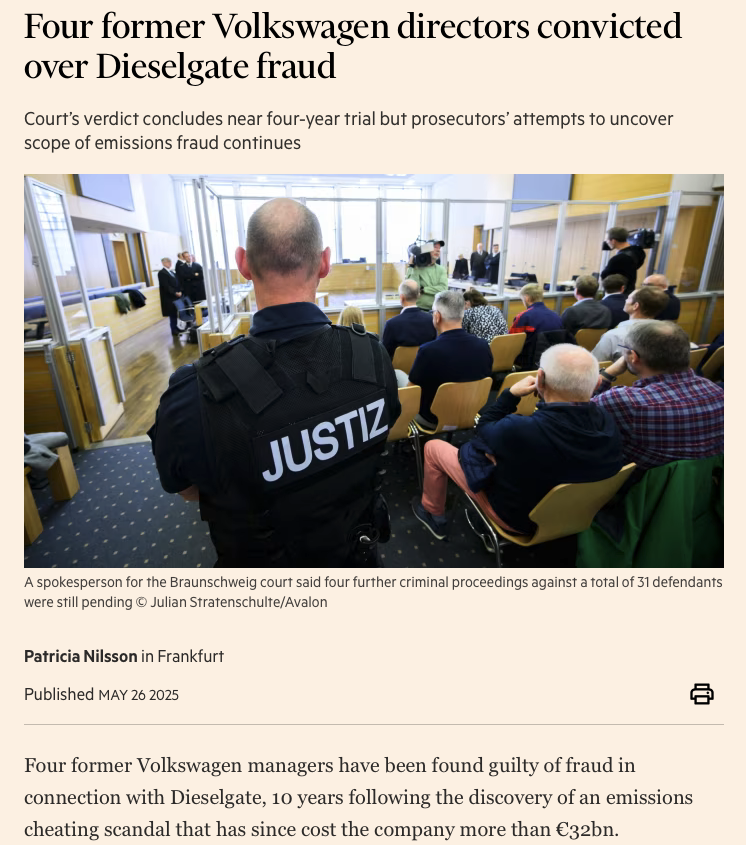

[FT (2025)](https://www.ft.com/content/f1932fdf-418b-4baf-b154-5b0d9e064a0c)

#### September 2015

##### September 3

VW engineers privately admitted to the US Environmental Protection Agency that 480,000 diesel cars had been fitted with illegal defeat devices to understate emissions

##### September 18

EPA publicly announced it had found software-based defeat devices on model year 2009-2015 VW and Audi diesel cars with 2-litre engines

##### September 23

Martin Winterkorn resigned as CEO, stating “I am not aware of any wrongdoing on my part”

[Ask FT (2026)](https://ask.ft.com/shared/hvMOsmLPhbIXSOCDQ7JhZbutaFLgrc99ECFgHCIJn4n0n6vXuroTSTIiLZXbi6o6mJEtU9q8CsTrdj77IXZhlTmML6)

## VW Dieselgate

### The timeline

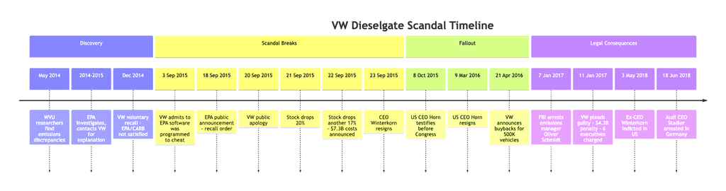

[See also FT (2015)](https://www.ft.com/content/346e7c64-0550-343c-90fb-ace89a2ff200)

## VW Dieselgate

### Why this matters for finance research and pratice

#### Research implications/opportunities

- Event study opportunity (Lecture 5 preview)
- Cross-firm contagion (did other automakers suffer?)
- Data challenges: Matching news to stock prices, firms to industries, prices to accounting data

#### Practical implications

- Risk management: How to price in such events?
- Regulatory oversight: Detecting fraud early
- Corporate governance: Preventing future scandals
- Legal consequences: Class-action lawsuits, fines

## VW Dieselgate

### What does it have to do with the assignments?

#### Assignments 1-5 use VW Dieselgate as a running example…

- Assignment 1: Data wrangling & visualization
- Assignment 2: visualization
- Assignment 3: Cross-sectional regression analysis (OLS)
- Assignment 4: Panel data regression analysis (DiD)
- Assignment 5: Event study analysis

## VW Dieselgate

### Assignment 1 walkthrough

#### The skinny

##### Data

- WRDS Compustat + CRSP
- auto_firms_raw.csv: Company identifiers and industry codes from Compustat
- auto_firms_prices.csv: Daily stock prices for automakers
- **All data provided** in the assignment folder on [JupyterHub](https://callisto.rsm.nl)

##### Your tasks

- Clean the header file (filter to relevant firms—German automakers including VW)
- Merge price data to get one analysis-ready “tidy” dataset
- Create basic variables (returns, log prices) and publication-quality tables
- **Teaser lecture 2**: Time-series plot of VW’s stock price with event annotation

> All details in the assignment document.

# Let’s check it out!

[JupyterHub](https://callisto.rsm.nl)

Thank You for Your Attention!

See You in the Next One!

## References

Huntington-Klein, Nick. 2022. *The Effect: An Introduction to Research Design and Causality*. 2nd ed. Chapman; Hall/CRC.

Verbeek, Marno. 2021. *Panel Methods for Finance: A Guide to Panel Data Econometrics for Financial Applications*. De Gruyter.

# Appendix

## Appendix

### Wrds Web Interface example

#### Accessing WRDS via web interface - Compustat

[figure not shown]